# task1_exp

```python
import numpy as np
import pandas as pd
import matplotlib.pyplot as plt
import seaborn as sns
import os
```

```python
path = os.path.dirname(os.getcwd()) + "/data/"
```

```python
data = pd.read_csv(path + "telco.csv").iloc[:-1]
```

```python
desc = pd.read_excel(path + "field_descriptions.xlsx").set_index("Fields")
```

```python
data.select_dtypes(exclude ="object").describe()
```

|  | Bearer Id | Start ms | End ms | Dur. (ms) | IMSI | MSISDN/Number | IMEI | Avg RTT DL (ms) | Avg RTT UL (ms) | Avg Bearer TP DL (kbps) | ... | Youtube DL (Bytes) | Youtube UL (Bytes) | Netflix DL (Bytes) | Netflix UL (Bytes) | Gaming DL (Bytes) | Gaming UL (Bytes) | Other DL (Bytes) | Other UL (Bytes) | Total UL (Bytes) | Total DL (Bytes) |
| --- | --- | --- | --- | --- | --- | --- | --- | --- | --- | --- | --- | --- | --- | --- | --- | --- | --- | --- | --- | --- | --- |
| count | 1.490100e+05 | 150000.000000 | 150000.000000 | 1.500000e+05 | 1.494310e+05 | 1.489350e+05 | 1.494290e+05 | 122172.000000 | 122189.000000 | 150000.000000 | ... | 1.500000e+05 | 1.500000e+05 | 1.500000e+05 | 1.500000e+05 | 1.500000e+05 | 1.500000e+05 | 1.500000e+05 | 1.500000e+05 | 1.500000e+05 | 1.500000e+05 |
| mean | 1.013887e+19 | 499.188200 | 498.800880 | 1.046086e+05 | 2.082016e+14 | 4.188282e+10 | 4.847455e+13 | 109.795706 | 17.662883 | 13300.045927 | ... | 1.163407e+07 | 1.100941e+07 | 1.162685e+07 | 1.100175e+07 | 4.220447e+08 | 8.288398e+06 | 4.211005e+08 | 8.264799e+06 | 4.112121e+07 | 4.546434e+08 |
| std | 2.893173e+18 | 288.611834 | 288.097653 | 8.103762e+04 | 2.148809e+10 | 2.447443e+12 | 2.241637e+13 | 619.782739 | 84.793524 | 23971.878541 | ... | 6.710591e+06 | 6.345445e+06 | 6.725240e+06 | 6.359511e+06 | 2.439683e+08 | 4.782716e+06 | 2.432058e+08 | 4.769020e+06 | 1.127639e+07 | 2.441429e+08 |
| min | 6.917538e+18 | 0.000000 | 0.000000 | 7.142000e+03 | 2.040471e+14 | 3.360100e+10 | 4.400152e+11 | 0.000000 | 0.000000 | 0.000000 | ... | 5.300000e+01 | 1.050000e+02 | 4.200000e+01 | 3.500000e+01 | 2.516000e+03 | 5.900000e+01 | 3.290000e+03 | 1.480000e+02 | 2.866892e+06 | 7.114041e+06 |
| 25% | 7.349883e+18 | 250.000000 | 251.000000 | 5.744050e+04 | 2.082014e+14 | 3.365130e+10 | 3.546071e+13 | 32.000000 | 2.000000 | 43.000000 | ... | 5.833482e+06 | 5.517962e+06 | 5.777095e+06 | 5.475977e+06 | 2.104706e+08 | 4.128424e+06 | 2.101824e+08 | 4.145904e+06 | 3.322201e+07 | 2.431068e+08 |
| 50% | 7.349883e+18 | 499.000000 | 500.000000 | 8.639900e+04 | 2.082015e+14 | 3.366371e+10 | 3.572201e+13 | 45.000000 | 5.000000 | 63.000000 | ... | 1.161601e+07 | 1.101348e+07 | 1.164222e+07 | 1.099631e+07 | 4.234082e+08 | 8.291215e+06 | 4.218057e+08 | 8.267086e+06 | 4.114331e+07 | 4.558411e+08 |
| 75% | 1.304243e+19 | 749.000000 | 750.000000 | 1.324302e+05 | 2.082018e+14 | 3.368349e+10 | 8.611970e+13 | 70.000000 | 15.000000 | 19710.750000 | ... | 1.744855e+07 | 1.651559e+07 | 1.747050e+07 | 1.650729e+07 | 6.331747e+08 | 1.243163e+07 | 6.316950e+08 | 1.238420e+07 | 4.903424e+07 | 6.657055e+08 |
| max | 1.318654e+19 | 999.000000 | 999.000000 | 1.859336e+06 | 2.140743e+14 | 8.823971e+14 | 9.900120e+13 | 96923.000000 | 7120.000000 | 378160.000000 | ... | 2.325910e+07 | 2.201196e+07 | 2.325919e+07 | 2.201196e+07 | 8.434419e+08 | 1.655879e+07 | 8.434425e+08 | 1.655882e+07 | 7.833131e+07 | 9.029696e+08 |

8 rows × 50 columns

## User Overview Analysis

- Start by identifying the top 10 handsets used by the customers.
- Then, identify the top 3 handset manufacturers
- Next, identify the top 5 handsets per top 3 handset manufacturer
- Make a short interpretation and recommendation to marketing teams

```python
new_data_col = [i.strip() for i in list(data.columns)]
```

```python
data.columns = new_data_col
```

```python
handset_data = data[['Handset Manufacturer', 'Handset Type',]]
```

```python
top10_handet = handset_data["Handset Type"][handset_data["Handset Type"] != "undefined"].value_counts()[:10]#.plot(kind = "bar")
```

```python
top3_manufacturers = handset_data["Handset Manufacturer"][handset_data["Handset Manufacturer"] != "undefined"].value_counts().head(3)
```

```python
handsets_by_top3_manufacturers = handset_data.set_index(keys= ["Handset Manufacturer"]).loc[top3_manufacturers.keys()]
```

```python
top5_of_top3_manufacturers_dict = dict()
for i in top3_manufacturers.keys():
    top5_of_top3_manufacturers_dict[i] = handsets_by_top3_manufacturers.loc[i, "Handset Type"].value_counts().head(5)
```

```python
top5_of_top3_manufacturers = pd.DataFrame.from_dict(top5_of_top3_manufacturers_dict, orient= "index").stack()
top5_of_top3_manufacturers.name = "count"
top5_of_top3_manufacturers = top5_of_top3_manufacturers.to_frame()
```

## Task 1.1

Aggregate per user the following information in the column

- number of xDR sessions
- session duration
- the total download (DL) and upload (UL) data
- the total data volume (in Bytes) during this session for each application

```python
data["MSISDN/Number"] = data["MSISDN/Number"].fillna(-999).astype("int")
```

```python
no_of_xdr_sessions = data["MSISDN/Number"].fillna("median").value_counts()
```

```python
total_sessions_duration = (data[["MSISDN/Number", "Dur. (ms)"]]
                           .fillna("mean").groupby(["MSISDN/Number"])["Dur. (ms)"]
                           .sum()
                          )/(1000*60)
```

```python
total_dl_ul_data = (data[["MSISDN/Number", "Total DL (Bytes)", "Total UL (Bytes)"]]
                    .fillna("mean").groupby(["MSISDN/Number"])[["Total DL (Bytes)", "Total UL (Bytes)"]]
                    .sum()
                   )/(2**20)
```

```python
total_dl_ul_data["total_data"] = total_dl_ul_data.sum(1)
```

```python
apps = ['Social Media DL (Bytes)', 'Social Media UL (Bytes)',
       'Google DL (Bytes)', 'Google UL (Bytes)', 'Email DL (Bytes)',
       'Email UL (Bytes)', 'Youtube DL (Bytes)', 'Youtube UL (Bytes)',
       'Netflix DL (Bytes)', 'Netflix UL (Bytes)', 'Gaming DL (Bytes)',
       'Gaming UL (Bytes)', 'Other DL (Bytes)', 'Other UL (Bytes)',]
```

```python
total_dl_ul_data_per_app = (data[apps + ["MSISDN/Number"]].fillna("mean")
                            .groupby(["MSISDN/Number"])[apps].sum()
                           )/(2**20)
```

```python
total_data_per_app = pd.DataFrame()
count = 0
for i,j in zip(range(len(total_dl_ul_data_per_app.columns)), total_dl_ul_data_per_app.columns):
    if count != 1:
        total_data_per_app[j.split()[0]] = total_dl_ul_data_per_app.iloc[:, i] + total_dl_ul_data_per_app.iloc[:,i+1]
        count = (count + 1) % 2
    else:
        count = (count + 1) % 2
        continue
```

```python
aggregates = (no_of_xdr_sessions.to_frame()
              .join(total_sessions_duration)
              .join(total_data_per_app)
              .join(total_dl_ul_data)
             )
```

```python
aggregates.index.name = "MSISDN"
aggregates.columns = ["tot number of session", "tot sessions duration (mins)", "social media data usage (GBs)",
                      "google data usage (MBs)","Email data usage (MBs)", "youtube data usage (MBs)",
                      "netflix data usage (MBs)",  "gaming apps data usage (MBs)", "other apps data usage (MBs)",
                     "tot downloaded data (MBs)", "tot uploaded data (MBs)", "tot data usage (MBs)",]
aggregates = aggregates.drop(index = -999)
```

```python
aggregates.iloc[1:].describe().style#.set_properties(**{"width": "100px"})
```

|  | tot number of session | tot sessions duration (mins) | social media data usage (GBs) | google data usage (MBs) | Email data usage (MBs) | youtube data usage (MBs) | netflix data usage (MBs) | gaming apps data usage (MBs) | other apps data usage (MBs) | tot downloaded data (MBs) | tot uploaded data (MBs) | tot data usage (MBs) |
| --- | --- | --- | --- | --- | --- | --- | --- | --- | --- | --- | --- | --- |
| count | 106855.000000 | 106855.000000 | 106855.000000 | 106855.000000 | 106855.000000 | 106855.000000 | 106855.000000 | 106855.000000 | 106855.000000 | 106855.000000 | 106855.000000 | 106855.000000 |
| mean | 1.393636 | 2.434771 | 2.429566 | 10.377037 | 3.002575 | 30.093374 | 30.074645 | 571.928183 | 570.714880 | 604.238777 | 54.649059 | 658.887836 |
| std | 0.804423 | 3.074552 | 1.815753 | 7.183554 | 2.116357 | 20.283853 | 20.284877 | 427.952270 | 427.557563 | 442.609005 | 33.958985 | 467.827678 |
| min | 1.000000 | 0.119033 | 0.001491 | 0.038462 | 0.017334 | 0.075248 | 0.176019 | 0.292166 | 0.142140 | 8.418161 | 2.734081 | 31.708726 |
| 25% | 1.000000 | 1.188450 | 1.155142 | 5.667295 | 1.596907 | 17.767647 | 17.696265 | 274.715029 | 272.326412 | 300.239505 | 34.709370 | 341.936917 |
| 50% | 1.000000 | 1.712317 | 2.196980 | 9.142036 | 2.670093 | 25.558805 | 25.480491 | 517.223645 | 514.816847 | 543.941679 | 44.625650 | 589.297327 |
| 75% | 2.000000 | 2.879983 | 3.154274 | 12.602436 | 3.668942 | 36.170600 | 36.217511 | 741.280156 | 739.457761 | 769.954566 | 62.685393 | 817.711762 |
| max | 17.000000 | 309.229233 | 37.940206 | 135.715404 | 38.899073 | 431.975144 | 381.011085 | 7390.434488 | 7285.369465 | 7778.876775 | 695.779209 | 8436.419004 |

## Task 1.2

○ Describe all relevant variables and associated data types (slide).

○ Analyze the basic metrics (mean, median, etc) in the Dataset (explain) & their importance for the global objective.

○ Conduct a Non-Graphical Univariate Analysis by computing dispersion parameters for each quantitative variable and providing useful interpretation.

○ Conduct a Graphical Univariate Analysis by identifying the most suitable plotting options for each variable and interpreting your findings.

○ Bivariate Analysis – explore the relationship between each application & the total DL+UL data using appropriate methods and interpret your findings.

○ Variable transformations – segment the users into the top five decile classes based on the total duration for all sessions and compute the total data (DL+UL) per decile class.

○ Correlation Analysis – compute a correlation matrix for the following variables and interpret your findings: Social Media data, Google data, Email data, Youtube data, Netflix data, Gaming data, Other data

○ Dimensionality Reduction – perform a principal component analysis to reduce the dimensions of your data and provide a useful interpretation of the results (Provide your interpretation in four (4) bullet points-maximum).

```python
aggregates.dtypes
```

```
tot number of session              int64
tot sessions duration (mins)     float64
social media data usage (GBs)    float64
google data usage (MBs)          float64
Email data usage (MBs)           float64
youtube data usage (MBs)         float64
netflix data usage (MBs)         float64
gaming apps data usage (MBs)     float64
other apps data usage (MBs)      float64
tot downloaded data (MBs)        float64
tot uploaded data (MBs)          float64
tot data usage (MBs)             float64
dtype: object
```

```python
ss = aggregates.describe().loc[["mean", "min", "50%", "75%", "max"]].T
```

```python
ss.style.set_precision(2).set_properties(**{"width": "100px", "color": "blue"})
```

|  | mean | min | 50% | 75% | max |
| --- | --- | --- | --- | --- | --- |
| tot number of session | 1.39 | 1.00 | 1.00 | 2.00 | 18.00 |
| tot sessions duration (mins) | 2.44 | 0.12 | 1.71 | 2.88 | 309.23 |
| social media data usage (GBs) | 2.43 | 0.00 | 2.20 | 3.15 | 41.37 |
| google data usage (MBs) | 10.38 | 0.04 | 9.14 | 12.60 | 145.14 |
| Email data usage (MBs) | 3.00 | 0.02 | 2.67 | 3.67 | 40.45 |
| youtube data usage (MBs) | 30.10 | 0.08 | 25.56 | 36.17 | 431.98 |
| netflix data usage (MBs) | 30.08 | 0.18 | 25.48 | 36.22 | 381.01 |
| gaming apps data usage (MBs) | 571.98 | 0.29 | 517.22 | 741.29 | 7390.43 |
| other apps data usage (MBs) | 570.78 | 0.14 | 514.82 | 739.48 | 7789.50 |
| tot downloaded data (MBs) | 604.30 | 8.42 | 543.95 | 769.96 | 7778.88 |
| tot uploaded data (MBs) | 54.65 | 2.73 | 44.63 | 62.69 | 695.78 |
| tot data usage (MBs) | 658.95 | 31.71 | 589.30 | 817.71 | 8436.42 |

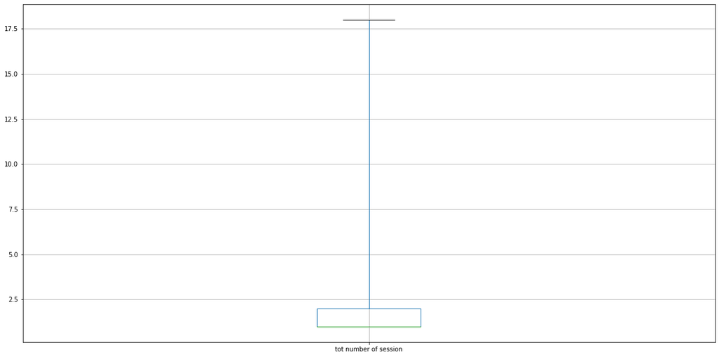

```python
aggregates.iloc[:,:1].boxplot(figsize= (20,10), whis= (0,100))
```

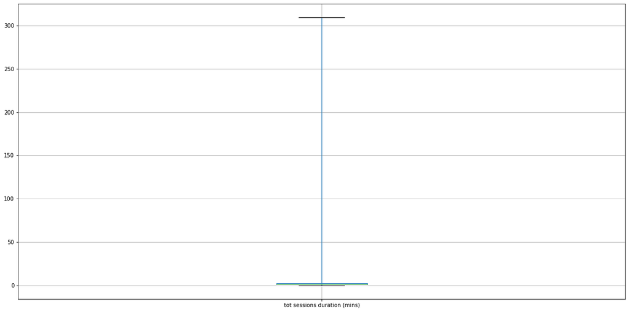

```python
aggregates.iloc[:,1:2].boxplot(figsize= (20,10), whis= (0,100))
```

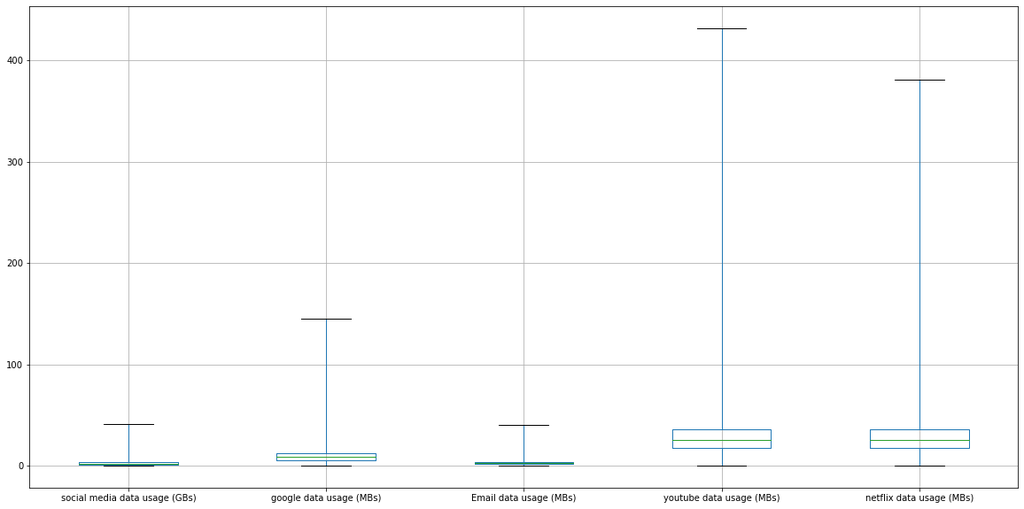

```python
aggregates.iloc[:,2:7].boxplot(figsize= (20,10), whis= (0,100))
```

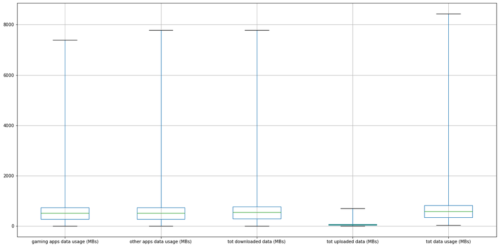

```python
aggregates.iloc[:,7:12].boxplot(figsize= (20,10), whis= (0,100))
```